# Sistemas y Señales Biomédicos

Ingeniería Biomédica

Ph.D. Pablo Eduardo Caicedo Rodríguez

2026-09-11

# Sistemas y Señales Biomedicos - SYSB

## Objective

- To demonstrate, in the **time domain**, how a Linear Time-Invariant (LTI) system responds to a sinusoidal input.
- We will start from the **convolution integral** and use **Euler’s identity** to show that the steady-state output remains sinusoidal.

## Introduction

Euler’s formula shows the deep connection between trigonometry and complex exponential functions:

$$e^{i\alpha} = \cos(\alpha) + i \sin(\alpha)$$

To prove this, we use the **Taylor Series** method at $a = 0$. This allows us to write complex functions as infinite sums of simple terms.

## Defining the Taylor Series

First, we define the standard power series for the three functions involved:

**Exponential Function:**
$$e^x = \sum_{n=0}^{\infty} \frac{x^n}{n!} = 1 + x + \frac{x^2}{2!} + \frac{x^3}{3!} + \frac{x^4}{4!} + \dots$$

**Trigonometric Functions:**
$$\cos(\alpha) = 1 - \frac{\alpha^2}{2!} + \frac{\alpha^4}{4!} - \frac{\alpha^6}{6!} + \dots$$
$$\sin(\alpha) = \alpha - \frac{\alpha^3}{3!} + \frac{\alpha^5}{5!} - \frac{\alpha^7}{7!} + \dots$$

## Complex Substitution

Next, we replace the variable $x$ in the exponential series with the imaginary term $i\alpha$:

$$e^{i\alpha} = 1 + (i\alpha) + \frac{(i\alpha)^2}{2!} + \frac{(i\alpha)^3}{3!} + \frac{(i\alpha)^4}{4!} + \dots$$

We must apply the powers of the imaginary unit $i$: * $i^2 = -1$ * $i^3 = -i$ * $i^4 = 1$ * $i^5 = i$

## Expanding the Series

After applying the powers of $i$, the series looks like this:

$$e^{i\alpha} = 1 + i\alpha - \frac{\alpha^2}{2!} - i\frac{\alpha^3}{3!} + \frac{\alpha^4}{4!} + i\frac{\alpha^5}{5!} - \dots$$

Now, we group the **Real** parts and the **Imaginary** parts:

$$e^{i\alpha} = \underbrace{\left( 1 - \frac{\alpha^2}{2!} + \frac{\alpha^4}{4!} - \dots \right)}_{\text{Real Part}} + i \underbrace{\left( \alpha - \frac{\alpha^3}{3!} + \frac{\alpha^5}{5!} - \dots \right)}_{\text{Imaginary Part}}$$

## Final Conclusion

We can now see that the two groups match the original Taylor series for Sine and Cosine:

1. The Real part is exactly $\cos(\alpha)$.
2. The Imaginary part is exactly $\sin(\alpha)$.

**Final Identity:**
$$e^{i\alpha} = \cos(\alpha) + i \sin(\alpha)$$

## The Rectangular Form

A complex number $z$ is typically written in Cartesian coordinates as:

$$z = a + bi$$

Where:

- **$a$**: The Real part ($\text{Re}\{z\}$)
- **$b$**: The Imaginary part ($\text{Im}\{z\}$)
- **$i$**: The imaginary unit ($\sqrt{-1}$)

## Geometry in the Complex Plane

We can treat $(a, b)$ as coordinates on a 2D plane (the Argand plane).

To convert to polar form, we define:

1. **Magnitude ($r$):** The distance from the origin.
   $$r = |z| = \sqrt{a^2 + b^2}$$
2. **Phase ($\alpha$):** The angle from the positive real axis.
   $$\alpha = \arg(z) = \tan^{-1}\left(\frac{b}{a}\right)$$

## From Trigonometry to Euler

From the geometry of a right triangle, we know: * $a = r \cos(\alpha)$ * $b = r \sin(\alpha)$

Substituting these into $z = a + bi$:
$$z = r \cos(\alpha) + i(r \sin(\alpha))$$
$$z = r (\cos(\alpha) + i \sin(\alpha))$$

Using **Euler’s Formula** ($e^{i\alpha} = \cos\alpha + i\sin\alpha$), we simplify this to:
$$z = r e^{i\alpha}$$

## Why Use Exponential Form?

In biomedical engineering, the form $z = r e^{i\alpha}$ is superior for calculations:

**1. Multiplication:**
$$z_1 z_2 = (r_1 e^{i\alpha_1})(r_2 e^{i\alpha_2}) = r_1 r_2 e^{i(\alpha_1 + \alpha_2)}$$

**2. Division:**
$$\frac{z_1}{z_2} = \frac{r_1}{r_2} e^{i(\alpha_1 - \alpha_2)}$$

**3. Signal Analysis:** It allows us to represent a rotating phasor, which is the basis for the Fourier Transform.

## Example: Converting $z = 1 + i$

1. **Calculate Magnitude:**
   $$r = \sqrt{1^2 + 1^2} = \sqrt{2}$$
2. **Calculate Angle:**
   $$\alpha = \tan^{-1}\left(\frac{1}{1}\right) = 45^\circ = \frac{\pi}{4} \text{ rad}$$
3. **Exponential Representation:**
   $$z = \sqrt{2} e^{i\frac{\pi}{4}}$$

## Summary

| Feature | Rectangular | Exponential |
| --- | --- | --- |
| **Notation** | $a + bi$ | $r e^{i\alpha}$ |
| **Best for** | Addition / Subtraction | Mult. / Div. / Powers |
| **Biomedical** | Signal Amplitude | Phase Shift Analysis |

$$e^{i\alpha} = \cos(\alpha) + i \sin(\alpha)$$

## 1. System Definition

A continuous-time LTI system is defined by:

$$y(t) = x(t) * h(t) = \int_{-\infty}^{\infty} h(\tau)\,x(t - \tau)\,d\tau$$

where

- $x(t)$ is the input,
- $h(t)$ is the impulse response,
- $y(t)$ is the output.

## 2. Sinusoidal Input

Let the input be a sinusoid:

$$x(t) = A \cos(\omega_0 t + \phi)$$

Using Euler’s identity:

$$x(t) = \frac{A}{2} \left[e^{j(\omega_0 t + \phi)} + e^{-j(\omega_0 t + \phi)}\right]$$

## 3. Linearity of the Convolution Integral

Because the system is **linear**, we can treat each exponential term separately:

$$y(t) = \frac{A}{2}\left[ y_1(t) + y_2(t) \right]$$
where
$$y_1(t) = \frac{A}{2} e^{j\phi} \int_{-\infty}^{\infty} h(\tau)\, e^{j\omega_0(t-\tau)}\, d\tau$$
$$y_2(t) = \frac{A}{2} e^{-j\phi} \int_{-\infty}^{\infty} h(\tau)\, e^{-j\omega_0(t-\tau)}\, d\tau$$

## 4. Simplifying Each Integral

We can factor out the term $e^{j\omega_0 t}$:

$$y_1(t) = e^{j\phi} e^{j\omega_0 t} \int_{-\infty}^{\infty} h(\tau)\, e^{-j\omega_0 \tau}\, d\tau$$

Let
$$H_1 = \int_{-\infty}^{\infty} h(\tau)\, e^{-j\omega_0 \tau}\, d\tau$$

Then,
$$y_1(t) = e^{j\phi} e^{j\omega_0 t} H_1$$

## 5. Combine the Two Parts

The total output is:

$$y(t) = \frac{A}{2}\left[e^{j\phi} H_1 e^{j\omega_0 t} + e^{-j\phi} H_1^* e^{-j\omega_0 t}\right]$$

If we express $H_1$ in polar form:
$$H_1 = |H_1| e^{j\theta}$$

Then,
$$y(t) = A |H_1| \cos(\omega_0 t + \phi + \theta)$$

## 6. Interpretation in Time Domain

- The output is a **cosine** at the **same frequency** $\omega_0$ as the input.
- Its **amplitude** is scaled by $|H_1|$, which depends on $h(t)$.
- Its **phase** is shifted by$\theta$, the argument of $H_1$.

$$\boxed{y(t) = A |H_1| \cos(\omega_0 t + \phi + \theta)}$$

## 1. System Definition

A discrete-time LTI system is defined by the **convolution sum**:

$$y[n] = \sum_{k=-\infty}^{\infty} h[k]\,x[n - k]$$

where

- $x[n]$ is the input sequence,
- $h[k]$ is the impulse response,
- $y[n]$ is the output sequence.

## 2. Sinusoidal Input

Let the input be a discrete sinusoid:

$$x[n] = A \cos(\omega_0 n + \phi)$$

Using Euler’s identity:

$$x[n] = \frac{A}{2}\left[e^{j(\omega_0 n + \phi)} + e^{-j(\omega_0 n + \phi)}\right]$$

## 3. Linearity of the Convolution Sum

Because the system is **linear**, each exponential term can be treated independently:

$$y[n] = \frac{A}{2}\left[y_1[n] + y_2[n]\right]$$

where
$$y_1[n] = e^{j\phi} \sum_{k=-\infty}^{\infty} h[k]\, e^{j\omega_0 (n - k)}$$
$$y_2[n] = e^{-j\phi} \sum_{k=-\infty}^{\infty} h[k]\, e^{-j\omega_0 (n - k)}$$

## 4. Simplifying Each Sum

We can factor out $e^{j\omega_0 n}$:

$$y_1[n] = e^{j\phi} e^{j\omega_0 n} \sum_{k=-\infty}^{\infty} h[k]\, e^{-j\omega_0 k}$$

Let
$$H_1 = \sum_{k=-\infty}^{\infty} h[k]\, e^{-j\omega_0 k}$$

Then,
$$y_1[n] = e^{j\phi} H_1 e^{j\omega_0 n}$$

Similarly,
$$y_2[n] = e^{-j\phi} H_1^* e^{-j\omega_0 n}$$

## 5. Combine the Two Parts

The total output becomes:

$$y[n] = \frac{A}{2}\left[e^{j\phi} H_1 e^{j\omega_0 n} + e^{-j\phi} H_1^* e^{-j\omega_0 n}\right]$$

If we write $H_1$ in polar form:
$$H_1 = |H_1| e^{j\theta}$$

Then,
$$y[n] = A |H_1| \cos(\omega_0 n + \phi + \theta)$$

## 6. Interpretation in Time Domain

- The output remains **sinusoidal** with the **same frequency** $\omega_0$.
- Its **amplitude** is scaled by $|H_1|$.
- Its **phase** is shifted by $\theta$.
- Complex exponential are proper functions (eigen functions) of LTI systems.

$$\boxed{y[n] = A |H_1| \cos(\omega_0 n + \phi + \theta)}$$

# Frequency Content

## Introduction

- Signals can be analyzed in both **time domain** and **frequency domain**.
- The **frequency content** of a signal describes how different frequency components contribute to the overall signal.
- Applications in **biomedical signals, audio processing, communications, and image processing**.

## Convolution in Time Domain

- Convolution is a fundamental operation in signal processing.
- Given two signals $x(t)$ and $h(t)$, their convolution is defined as:

$$y(t) = x(t) * h(t) = \int_{-\infty}^{\infty} x(\tau) h(t - \tau) d\tau$$

- In **discrete-time**, convolution is:

$$y[n] = \sum_{k=-\infty}^{\infty} x[k] h[n-k]$$

## Convolution Theorem

- **Convolution in time domain corresponds to multiplication in frequency domain**:

$$X(f) H(f) = Y(f)$$

- This property is crucial in filter design and system analysis.

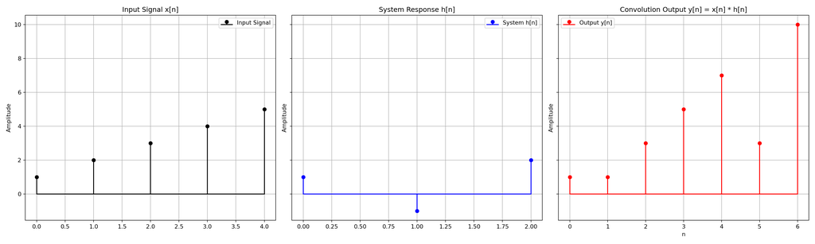

## Introduction to Fourier Series

```
(-1.0, 4.0)
```

```
(-1.0, 4.0)
```

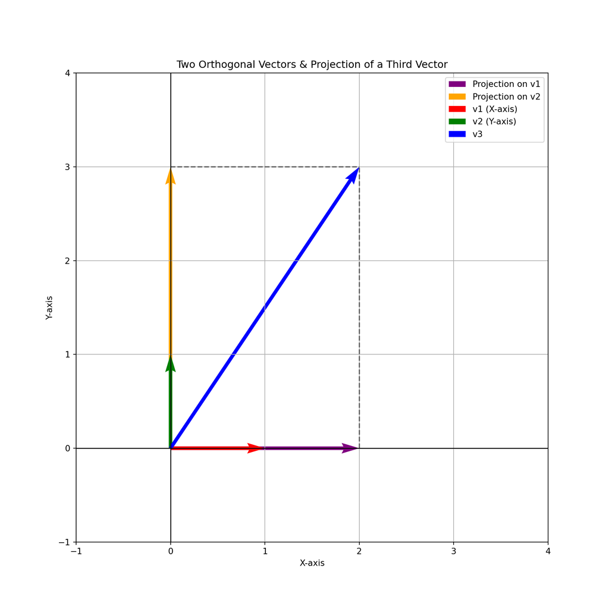

## Introduction to Fourier Series

- **Convolution** requiere the representation of the signal in a sum of impulse functions.
- **Fourier series** represents periodic signals as a sum of sinusoids:

$$x(t) = \sum_{n=-\infty}^{\infty} C_n e^{jn\omega_0 t}$$

where $C_n$ are the Fourier coefficients.

- Decomposing a signal into sinusoidal components allows **frequency analysis**.

## Fourier Coefficients

- The Fourier coefficients$C_n$are computed as:

$$C_n = \frac{1}{T} \int_{0}^{T} x(t) e^{-jn\omega_0 t} dt$$

- Determines how much of each frequency is present in the signal.

## Example of Fourier Series Expansion

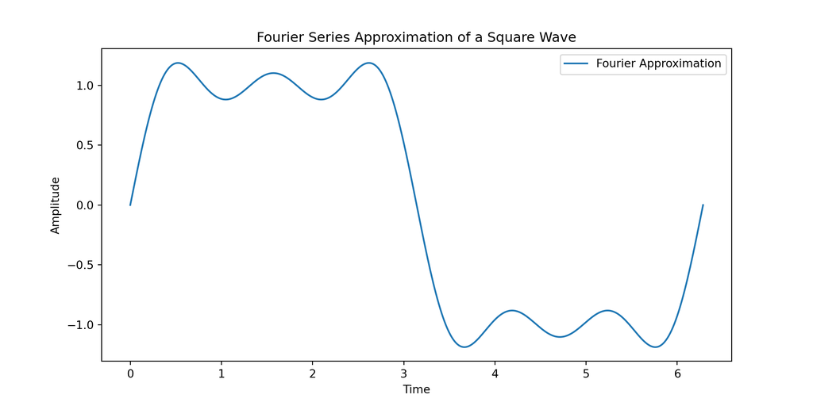

## 1. Definition of the Complex Fourier Series

For a periodic signal $x(t)$ with period $T$:

$$x(t) = \sum_{k=-\infty}^{\infty} c_k e^{j k \Omega_0 t},$$

where:

$$c_k = \frac{1}{T} \int_{T_0}^{T_0 + T} x(t)e^{-jk\Omega_0 t}\,dt, \quad
\Omega_0 = \frac{2\pi}{T}.$$

## 2. Example Signal

We define a periodic signal $x(t)$ with period $2\pi$:

$$x(t) =
\begin{cases}
0, & -\pi \le t < 0,\\
1, & 0 \le t < \pi.
\end{cases}$$

This corresponds to a **50% duty cycle pulse**.

## 3. Symbolic Derivation using SymPy

Expected result:

$$c_k =
\begin{cases}
\dfrac{1}{2}, & k=0,\\[4pt]
\dfrac{j\left((-1)^k - 1\right)}{2\pi k}, & k \ne 0.
\end{cases}$$

## 4. Numerical Evaluation (NumPy)

```python
import numpy as np
import pandas as pd

def ck_numeric(k):
    k = np.asarray(k, dtype=float)
    return np.where(
        k != 0,
        1j*(np.exp(1j*np.pi*k)-1)/(2*np.pi*k),
        0.5
    )

K = 10
ks = np.arange(-K, K+1)
cks = ck_numeric(ks)

pd.DataFrame({
    "k": ks,
    "Re{c_k}": np.real(cks),
    "Im{c_k}": np.imag(cks),
    "|c_k|": np.abs(cks)
})
```

```
     k       Re{c_k}   Im{c_k}         |c_k|
0  -10  1.949086e-17 -0.000000  1.949086e-17
1   -9 -1.949086e-17  0.035368  3.536777e-02
2   -8  1.949086e-17 -0.000000  1.949086e-17
3   -7 -1.949086e-17  0.045473  4.547284e-02
4   -6  1.949086e-17 -0.000000  1.949086e-17
5   -5 -1.949086e-17  0.063662  6.366198e-02
6   -4  1.949086e-17 -0.000000  1.949086e-17
7   -3 -1.949086e-17  0.106103  1.061033e-01
8   -2  1.949086e-17 -0.000000  1.949086e-17
9   -1 -1.949086e-17  0.318310  3.183099e-01
10   0  5.000000e-01  0.000000  5.000000e-01
11   1 -1.949086e-17 -0.318310  3.183099e-01
12   2  1.949086e-17  0.000000  1.949086e-17
13   3 -1.949086e-17 -0.106103  1.061033e-01
14   4  1.949086e-17  0.000000  1.949086e-17
15   5 -1.949086e-17 -0.063662  6.366198e-02
16   6  1.949086e-17  0.000000  1.949086e-17
17   7 -1.949086e-17 -0.045473  4.547284e-02
18   8  1.949086e-17  0.000000  1.949086e-17
19   9 -1.949086e-17 -0.035368  3.536777e-02
20  10  1.949086e-17  0.000000  1.949086e-17
```

## 5. Partial Sum Reconstruction

```python
import numpy as np
import matplotlib.pyplot as plt

def x_numeric(t):
    # Original pulse over [-π, π): 0 on [-π,0), 1 on [0,π).
    tw = ((t + np.pi) % (2*np.pi)) - np.pi
    return np.where((tw >= 0) & (tw < np.pi), 1.0, 0.0)

def partial_sum(t, N):
    ks = np.arange(-N, N+1)
    cks = ck_numeric(ks)
    return np.sum(cks[:, None] * np.exp(1j*np.outer(ks, t)), axis=0)

tgrid = np.linspace(-2*np.pi, 2*np.pi, 4000, endpoint=False)
xg = x_numeric(tgrid)
```

## 6. Reconstruction for N = 5

```python
N1 = 5
sN1 = partial_sum(tgrid, N1).real

plt.figure(figsize=(8,3))
plt.plot(tgrid, xg, label='x(t) original')
plt.plot(tgrid, sN1, label=f'N={N1}')
plt.xlim([-2*np.pi, 2*np.pi])
```

```
(-6.283185307179586, 6.283185307179586)
```

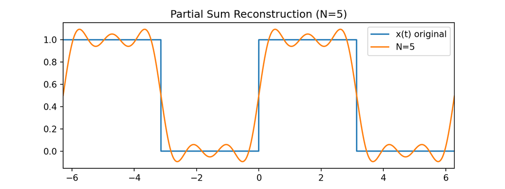

```python
plt.legend()
plt.title("Partial Sum Reconstruction (N=5)")
plt.show()
```

## 7. Reconstruction for N = 20

```
(-6.283185307179586, 6.283185307179586)
```

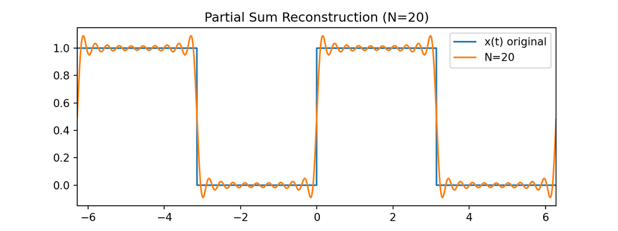

## 7. Reconstruction for N = 100

```
(-6.283185307179586, 6.283185307179586)
```

[figure not shown]

## 8. Discussion

- The average value $c_0 = 0.5$ matches the mean level of the pulse.
- As $N$ increases, the reconstruction converges except near discontinuities.
- The **Gibbs phenomenon** appears at the jump discontinuities.
- The error $\lVert x(t)-S_N(t)\rVert_2$ decreases with $N$.

## 9. Summary

| Concept | Expression |
| --- | --- |
| Fundamental frequency | $\Omega_0 = \frac{2\pi}{T}$ |
| Coefficient $c_k$ | $\frac{1}{T}\int x(t)e^{-jk\Omega_0 t}dt$ |
| Reconstructed signal | $S_N(t) = \sum_{k=-N}^{N} c_k e^{jk\Omega_0 t}$ |
| Example $x(t)$ | Half-wave pulse in $[-\pi, \pi)$ |

## Example 2 of Fourier Series

```
(array([-5.,  0.,  5., 10., 15., 20., 25., 30., 35.]), [Text(-5.0, 0, '−5'), Text(0.0, 0, '0'), Text(5.0, 0, '5'), Text(10.0, 0, '10'), Text(15.0, 0, '15'), Text(20.0, 0, '20'), Text(25.0, 0, '25'), Text(30.0, 0, '30'), Text(35.0, 0, '35')])
```

```
(array([4.5, 5. , 5.5, 6. , 6.5, 7. , 7.5, 8. , 8.5]), [Text(0, 4.5, '4.5'), Text(0, 5.0, '5.0'), Text(0, 5.5, '5.5'), Text(0, 6.0, '6.0'), Text(0, 6.5, '6.5'), Text(0, 7.0, '7.0'), Text(0, 7.5, '7.5'), Text(0, 8.0, '8.0'), Text(0, 8.5, '8.5')])
```

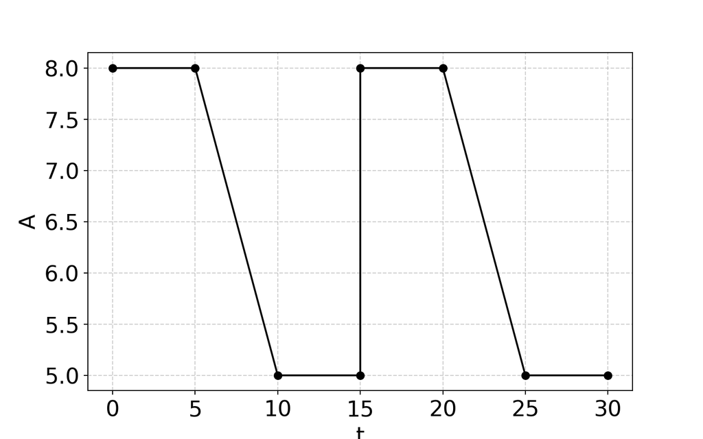

## Example 2 of Fourier Series

```
(array([-40., -30., -20., -10.,   0.,  10.,  20.,  30.,  40.]), [Text(-40.0, 0, '−40'), Text(-30.0, 0, '−30'), Text(-20.0, 0, '−20'), Text(-10.0, 0, '−10'), Text(0.0, 0, '0'), Text(10.0, 0, '10'), Text(20.0, 0, '20'), Text(30.0, 0, '30'), Text(40.0, 0, '40')])
```

```
(array([4.5, 5. , 5.5, 6. , 6.5, 7. , 7.5, 8. , 8.5]), [Text(0, 4.5, '4.5'), Text(0, 5.0, '5.0'), Text(0, 5.5, '5.5'), Text(0, 6.0, '6.0'), Text(0, 6.5, '6.5'), Text(0, 7.0, '7.0'), Text(0, 7.5, '7.5'), Text(0, 8.0, '8.0'), Text(0, 8.5, '8.5')])
```

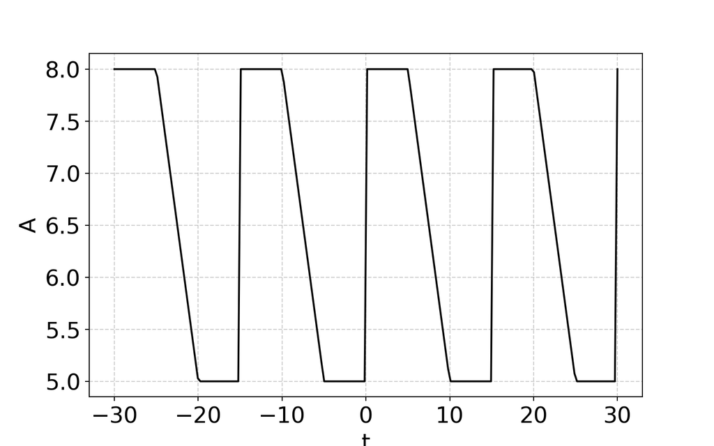

## **Linearity**

- If$f_1(x)$and$f_2(x)$have Fourier series,
- Then for any constants$a, b$,
- $a f_1(x) + b f_2(x)$ has a Fourier series,
- With coefficients scaled accordingly.

## **Time Shifting**

- If $f(x)$ has Fourier coefficients $a_n, b_n$,
- Then $f(x - x_0)$ has coefficients:
- $a_n \cos(n\omega x_0) + b_n \sin(n\omega x_0)$,
- And $b_n \cos(n\omega x_0) - a_n \sin(n\omega x_0)$.

## **Differentiation Property**

- If $f(x)$ is differentiable,
- Then $f'(x)$ has Fourier series,
- With coefficients scaled as $n a_n, n b_n$,
- Higher frequencies get amplified.

## **Integration Property**

- If $f(x)$ has a Fourier series,
- Then $\int f(x) dx$ has a Fourier series,
- With coefficients scaled as $\frac{a_n}{n}, \frac{b_n}{n}$,
- Lower frequencies get emphasized.

## **Parseval’s Theorem**

- The total signal energy is conserved,
- Energy in time domain equals energy in frequency domain,
- Given by:
- $\sum (a_n^2 + b_n^2) = \frac{1}{T} \int |f(x)|^2 dx$.

## **Convolution Property**

- Convolution in time domain,
- Is multiplication in Fourier series coefficients,
- If $f_1$ and $f_2$ are convoluted,
- Their Fourier coefficients multiply component-wise.

## **Discrete Time Fourier Series**

- Represents periodic discrete signals using harmonics.
- Extends Fourier series to discrete-time domain.
- Fundamental in digital signal processing.
- Basis for the Discrete Fourier Transform (DFT).

## **Mathematical Expression**

- A periodic sequence $x[n]$ can be expressed as:
- $$x[n] = \sum_{k=0}^{N-1} C_k e^{j(2\pi k n / N)}$$
  .
- The coefficients $C_k$ are computed as:
- $$C_k = \frac{1}{N} \sum_{n=0}^{N-1} x[n] e^{-j(2\pi k n / N)}$$
  .

## **Periodicity and Symmetry**

- The coefficients $C_k$ repeat every $N$.
- Ensures correct reconstruction of signals.
- Explains frequency domain representation.
- Basis for spectral analysis.

## **Key Properties**

- **Linearity**: Superposition holds.
- **Time Shift**: Causes phase shift in coefficients.
- **Parseval’s Theorem**: Energy conservation.
- **Convolution**: Time convolution → Frequency multiplication.

## **Frequency Domain Interpretation**

- $C_k$ represents discrete frequency content.
- The spectrum consists of $N$ harmonics.
- Resolution improves with larger $N$.
- Essential for analyzing periodic discrete signals.

## **Comparison with Continuous Case**

- DTFS applies to discrete periodic signals.
- Continuous Fourier series applies to continuous functions.
- Both represent signals as sums of sinusoids.
- DTFS is used in digital communications and audio processing.

## Example of th DTFS

```
DTFS Coefficients:
```

```
C[0] = 2.0000+0.0000j
C[1] = -0.6036-0.6036j
C[2] = 0.0000+0.0000j
C[3] = 0.1036-0.1036j
C[4] = 0.0000+0.0000j
C[5] = 0.1036+0.1036j
C[6] = 0.0000+0.0000j
C[7] = -0.6036+0.6036j
```

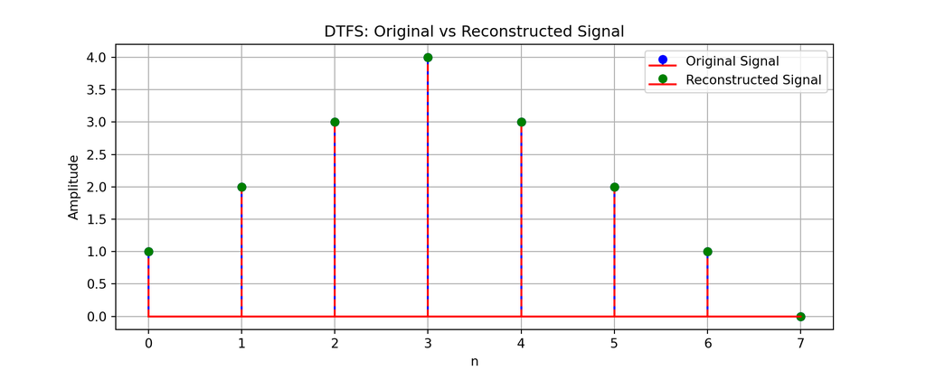

## Example 02

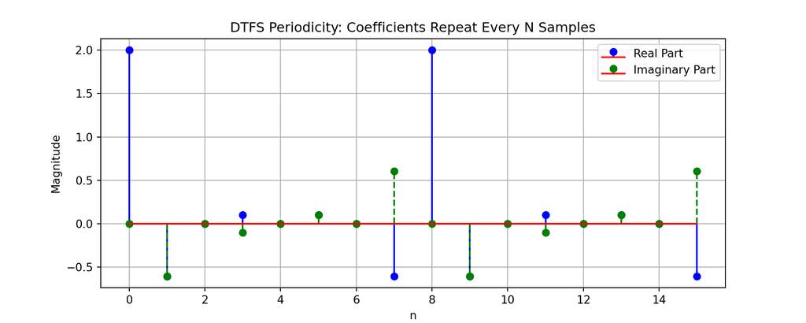

## **Conceptual Foundation**

- Fourier Series represents periodic signals in terms of sinusoids.
- As period $T \to \infty$, the signal becomes aperiodic.
- The Fourier Transform generalizes Fourier Series to aperiodic signals.
- Transforms signals from time to frequency domain.

## **Mathematical Transition**

- Fourier Series of a periodic signal:
- $$f(x) = \sum_{n=-\infty}^{\infty} C_n e^{j(2\pi n x / T)}$$
  .
- As $T \to \infty$, frequency spacing $\frac{1}{T}$ → differential.
- Leads to the Fourier Transform:
- $$F(\omega) = \int_{-\infty}^{\infty} f(x) e^{-j\omega x} dx$$
  .

## **Frequency Spectrum Interpretation**

- Fourier Series: discrete frequency spectrum.
- Fourier Transform: continuous frequency spectrum.
- Coefficients $C_n$ become the function $F(\omega)$.
- Allows analysis of arbitrary signals in frequency domain.

## **Inverse Fourier Transform**

- Recovers time-domain signal from $F(\omega)$.
- Defined as:
- $$f(x) = \frac{1}{2\pi} \int_{-\infty}^{\infty} F(\omega) e^{j\omega x} d\omega$$
  .
- Ensures complete information preservation.
- Basis for signal reconstruction in DSP.

## **Energy and Parseval’s Theorem**

- Energy conservation in time and frequency domains.
- Parseval’s theorem states:
- $$\int |f(x)|^2 dx = \frac{1}{2\pi} \int |F(\omega)|^2 d\omega$$
- Ensures no energy loss between domains.

## Definitions

For a continuous-time signal $x(t)$, its Fourier transform is

$$X(\omega)=\int_{-\infty}^{\infty} x(t)e^{-j\omega t}\,dt$$

For a discrete-time signal $x[n]$, its Fourier transform is

$$X(e^{j\omega})=\sum_{n=-\infty}^{\infty} x[n]e^{-j\omega n}$$

We will prove:

1. **Symmetry**: if the signal is real, then
   $$X(-\omega)=X^*(\omega)$$
2. **Periodicity** in discrete time:
   $$X(e^{j(\omega+2\pi)})=X(e^{j\omega})$$

## Proof of symmetry for a real signal

Assume $x(t)\in\mathbb{R}$. Then

$$X(\omega)=\int_{-\infty}^{\infty} x(t)e^{-j\omega t}\,dt$$

Take complex conjugate:

$$X^*(\omega)
=
\left(\int_{-\infty}^{\infty} x(t)e^{-j\omega t}\,dt\right)^*$$

Because $x(t)$ is real, $x^*(t)=x(t)$. Therefore

$$X^*(\omega)
=
\int_{-\infty}^{\infty} x(t)e^{j\omega t}\,dt$$

But

$$X(-\omega)
=
\int_{-\infty}^{\infty} x(t)e^{-j(-\omega)t}\,dt
=
\int_{-\infty}^{\infty} x(t)e^{j\omega t}\,dt$$

Hence

$$\boxed{X(-\omega)=X^*(\omega)}$$

This is called **conjugate symmetry**.

## Consequences of symmetry

From

$$X(-\omega)=X^*(\omega)$$

we get two useful results:

### 1. Magnitude is even

$$|X(-\omega)|=|X(\omega)|$$

### 2. Phase is odd

If $X(\omega)=|X(\omega)|e^{j\phi(\omega)}$, then

$$\phi(-\omega)=-\phi(\omega)$$

So, for a **real signal**:

- the **magnitude spectrum** is mirrored around $0$,
- the **phase spectrum** changes sign.

The same proof works for the DTFT if $x[n]$ is real.

## Proof of periodicity for the DTFT

Start from the DTFT:

$$X(e^{j\omega})=\sum_{n=-\infty}^{\infty} x[n]e^{-j\omega n}$$

Now evaluate it at $\omega+2\pi$:

$$X(e^{j(\omega+2\pi)})
=
\sum_{n=-\infty}^{\infty} x[n]e^{-j(\omega+2\pi)n}$$

Separate the exponential:

$$X(e^{j(\omega+2\pi)})
=
\sum_{n=-\infty}^{\infty} x[n]e^{-j\omega n}e^{-j2\pi n}$$

Because $n$ is an integer,

$$e^{-j2\pi n}=1$$

for every integer $n$. Then

$$X(e^{j(\omega+2\pi)})
=
\sum_{n=-\infty}^{\infty} x[n]e^{-j\omega n}
=
X(e^{j\omega})$$

So,

$$\boxed{X(e^{j(\omega+2\pi)})=X(e^{j\omega})}$$

More generally,

$$\boxed{X(e^{j(\omega+2\pi k)})=X(e^{j\omega}),\quad k\in\mathbb{Z}}$$

## Why the CTFT is not periodic in general

For the continuous-time Fourier transform,

$$X(\omega)=\int_{-\infty}^{\infty} x(t)e^{-j\omega t}\,dt$$

Now test $\omega+2\pi$:

$$X(\omega+2\pi)
=
\int_{-\infty}^{\infty} x(t)e^{-j(\omega+2\pi)t}\,dt
=
\int_{-\infty}^{\infty} x(t)e^{-j\omega t}e^{-j2\pi t}\,dt$$

Here is the key point:

- in DTFT, $n$ is integer, so $e^{-j2\pi n}=1$,
- in CTFT, $t$ is continuous, so $e^{-j2\pi t}\neq 1$ in general.

Therefore, in general,

$$\boxed{X(\omega+2\pi)\neq X(\omega)}$$

So the **CTFT is not periodic in general**.

## One simple discrete-time example

Let

$$x[n]=\delta[n]+\delta[n-1]$$

Its DTFT is

$$X(e^{j\omega})=1+e^{-j\omega}$$

Factor it:

$$X(e^{j\omega})
=
e^{-j\omega/2}\left(e^{j\omega/2}+e^{-j\omega/2}\right)
=
2\cos\left(\frac{\omega}{2}\right)e^{-j\omega/2}$$

Magnitude:

$$|X(e^{j\omega})|=2\left|\cos\left(\frac{\omega}{2}\right)\right|$$

This magnitude is:

- **even** in $\omega$,
- **$2\pi$-periodic**.

So this example shows both properties at the same time.

## Visual summary

[figure not shown]

## Final conclusion

### Continuous-time Fourier transform (CTFT)

If $x(t)$ is real:

$$\boxed{X(-\omega)=X^*(\omega)}$$

So the spectrum is **symmetric** in the conjugate sense, but **not periodic in general**.

### Discrete-time Fourier transform (DTFT)

For any $x[n]$:

$$\boxed{X(e^{j(\omega+2\pi)})=X(e^{j\omega})}$$

So the spectrum is **periodic**.

If $x[n]$ is also real, then:

$$\boxed{X(e^{-j\omega})=X^*(e^{j\omega})}$$

So the DTFT spectrum is **both periodic and symmetric**.